# 第五章： 专题 1： 点数据分析

##### 设施邻近性对比

###### **4.6 到公交站、地铁站的距离比较**

本节分别计算六区微博记录位置到最近公交站、地铁站的**直线距离**，在各区内比较AOI内外的分布。公交与地铁分开作图，同一设施图使用共同距离轴。

**最近设施的搜索范围**

微博记录按研究区分组，最近设施在**上海全市公交或地铁POI**中寻找，以保留区外的近邻站点。点到点的直线距离用于衡量设施邻近性；实际可达性还受入口、班次与出行条件等影响（[Cooke et al., 2022](https://doi.org/10.3389/frsc.2022.811049)）。

**代码阅读顺序**

1. **统一米制投影**，使微博点与设施点可以计算距离。
2. **关联 AOI 分组**，依据记录位置与多边形的关系，标记 AOI 内外。
3. **匹配最近设施**，用 `st_nearest_feature()` 找到对应站点，再以 `by_element = TRUE` 逐对计算距离，避免创建完整距离矩阵。
4. **查看云雨图**，结合半密度轮廓、细箱线与点阵，观察中间分布和长尾；红色菱形标出原始距离的均值。
5. **比较均值差**，在每个区内估计AOI外减AOI内的均值差，按用户账号计算聚类稳健标准误，并对12项比较统一作Holm校正。

图下代码依次分为**距离计算、统计检验、分布准备、点阵整理、绘图函数、出图、保存结果**七个模块。完整函数保留在同一开关内，按内部编号阅读；无需在运行各模块前重复安装或加载包。

**完整记录与展示子样本，分别用于什么？**

箱体、胡须、均值与检验使用**全部有效记录**，不因远距离或箱线图离群标记而删除记录。横轴用 `pseudo_log(sigma = 50)` 压缩长尾：0附近近似线性，较远距离逐渐压缩，标签仍以米表示。

规则点阵固定随机种子，**每组最多随机展示260条记录，另补真实最小值与最大值**。每点最多表示5条展示记录，不足5条时颜色较淡；点位对齐分箱中心，不能读取精确距离。**各组总量看记录数标签和统计表，不能按点的多少比较。**

半密度轮廓由全部记录在压缩视图中估计，在0处反射以避免负距离；各组轮廓归一化到相同高度，用于观察分布形状。

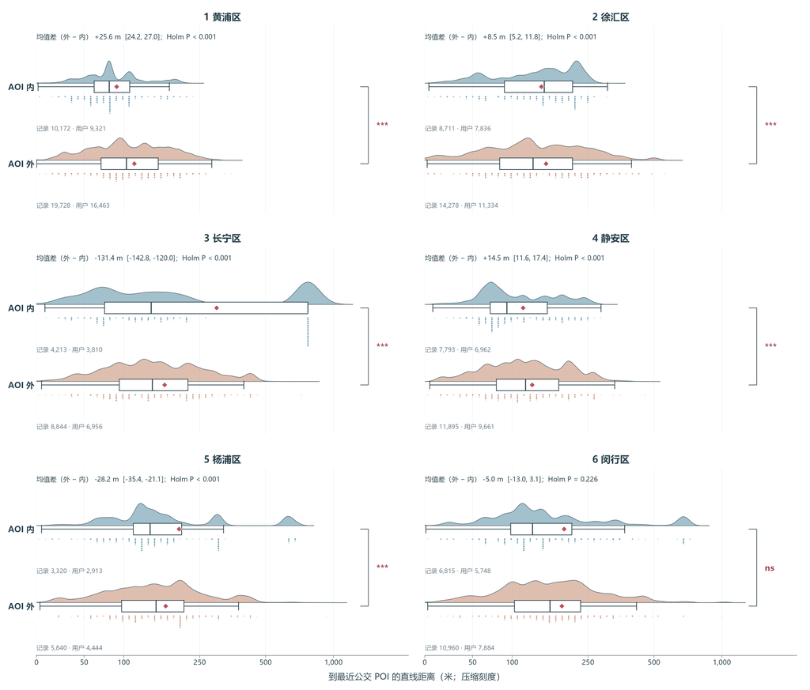

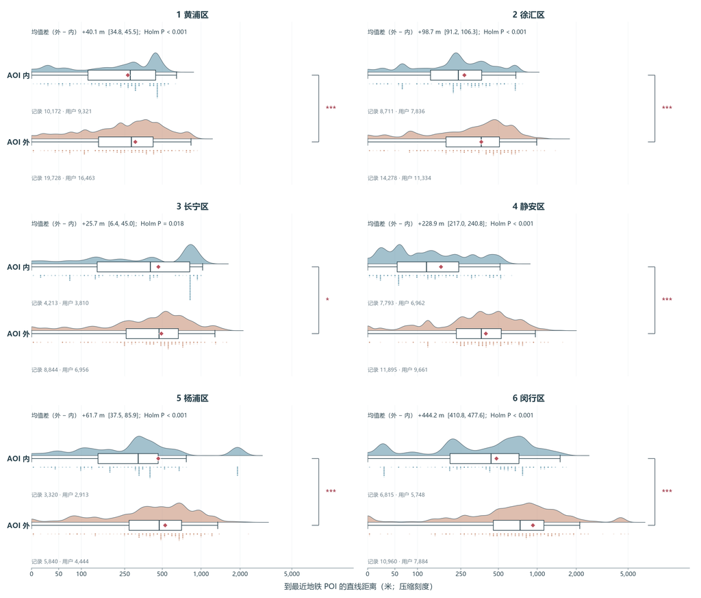

到最近地铁POI的云雨图。均值差为AOI外减AOI内，方括号为逐项95%置信区间。规则点阵来自固定子样本，每点最多5条；不足5条颜色更淡，点位对齐分箱中心，不代表精确距离。

**12 · 计算最近设施距离与分组统计**

```r
# 模块 12 · 计算最近设施距离与分组统计 ----------------------
# 使用全部有效研究记录与全市交通 POI；输出 distance_long 和分组统计。

# 最近设施可在研究区之外，因此保留全上海公交/地铁POI参与匹配。
# st_nearest_feature给出最近设施的行号；by_element逐条计算对应点对的距离。
# 两类几何已统一为UTM米制投影，因此st_distance返回的距离单位为米。
weibo_study$subway_m <- as.numeric(
  st_distance(
    weibo_study,
    subway_proj[st_nearest_feature(weibo_study, subway_proj), ],
    by_element = TRUE
  )
)
weibo_study$bus_m <- as.numeric(
  st_distance(
    weibo_study,
    bus_proj[st_nearest_feature(weibo_study, bus_proj), ],
    by_element = TRUE
  )
)
distance_long <- st_drop_geometry(weibo_study) %>%
  dplyr::select(district_name, user_id, aoi_group, bus_m, subway_m) %>%
  pivot_longer(
    c(bus_m, subway_m),
    names_to = "facility",
    values_to = "distance_m"
  ) %>%
  mutate(
    facility = factor(
      facility,
      levels = c("bus_m", "subway_m"),
      labels = c("公交", "地铁")
    )
  )
stopifnot(
  all(is.finite(distance_long$distance_m)),
  all(distance_long$distance_m >= 0)
)
distance_summary <- distance_long %>%
  group_by(district_name, facility, aoi_group) %>%
  summarise(
    n = n(),
    users = n_distinct(user_id),
    median_m = median(distance_m),
    q25_m = quantile(distance_m, 0.25),
    q75_m = quantile(distance_m, 0.75),
    p95_m = quantile(distance_m, 0.95),
    max_m = max(distance_m),
    within_500m_percent = 100 * mean(distance_m <= 500),
    .groups = "drop"
  )
write_csv(distance_summary, file.path(result_dir, "distance_summary.csv"))
```

**13 · 用户聚类稳健检验与 Holm 校正**

```r
# 模块 13 · 用户聚类稳健检验与 Holm 校正 ----------------------
# 基于 distance_long 计算原始米制均值差；12项比较统一校正。

# 目标量为 AOI 外减 AOI 内的记录加权均值差，不把重复记录当作独立访客。
# CR1 聚类稳健标准误允许同一账号内的记录相关；区间为逐项95%置信区间。
# AOI 在此视为固定；该探索性比较未传播 AOI 估计或跨用户空间相关的不确定性。
# 1) 定义单项检验：估计差值、用户聚类标准误与逐项置信区间。
cluster_mean_test <- function(data) {
  stopifnot(
    all(is.finite(data$distance_m)), all(data$distance_m >= 0),
    !anyNA(data$user_id), all(nzchar(data$user_id)),
    all(c("AOI 内", "AOI 外") %in% as.character(data$aoi_group))
  )
  model_data <- data.frame(
    distance_m = data$distance_m,
    group_out = as.integer(data$aoi_group == "AOI 外"),
    user_id = data$user_id
  )
  fit <- lm(distance_m ~ group_out, data = model_data)
  design <- model.matrix(fit)
  cluster_scores <- rowsum(
    design * residuals(fit), model_data$user_id, reorder = FALSE
  )
  n_records <- nrow(model_data)
  n_users <- n_distinct(model_data$user_id)
  stopifnot(n_users > 2L, n_records > ncol(design))

  bread <- solve(crossprod(design))
  correction <- n_users / (n_users - 1) *
    (n_records - 1) / (n_records - ncol(design))
  robust_vcov <- correction *
    bread %*% crossprod(cluster_scores) %*% bread
  estimate_m <- unname(coef(fit)[[2]])
  se_m <- sqrt(robust_vcov[2, 2])
  critical_t <- qt(0.975, df = n_users - 1)

  tibble(
    n_records = n_records, n_user_clusters = n_users,
    mean_inside_m = mean(data$distance_m[data$aoi_group == "AOI 内"]),
    mean_outside_m = mean(data$distance_m[data$aoi_group == "AOI 外"]),
    estimate_out_minus_in_m = estimate_m,
    se_user_cluster_m = se_m,
    ci_low_m = estimate_m - critical_t * se_m,
    ci_high_m = estimate_m + critical_t * se_m,
    t_statistic = estimate_m / se_m,
    df = n_users - 1,
    p_raw = 2 * pt(-abs(estimate_m / se_m), df = n_users - 1)
  )
}

# 2) 按“区 × 设施”运行检验，最后在完整比较家族内作 Holm 校正。
# 先计算全部 12 项比较，再统一校正；公交与地铁不分成两次校正。
distance_tests <- distance_long %>%
  group_by(district_name, facility) %>%
  group_modify(~ cluster_mean_test(.x)) %>%
  ungroup() %>%
  mutate(
    p_holm = p.adjust(p_raw, method = "holm"),
    significance = case_when(
      p_holm < 0.001 ~ "***",
      p_holm < 0.01 ~ "**",
      p_holm < 0.05 ~ "*",
      TRUE ~ "ns"
    )
  )
stopifnot(nrow(distance_tests) == 12L, !anyNA(distance_tests$p_holm))
write_csv(distance_tests, file.path(result_dir, "distance_cluster_tests.csv"))
```

**14 · 准备云雨图统计与半密度轮廓**

```r
# 模块 14 · 准备云雨图统计与半密度轮廓 ----------------------
# 使用完整距离记录；输出 distance_view、box_summary 和 density_polygons。

# pseudo_log 在 0 附近平滑过渡；这里只变换显示，不删远点或改变检验目标。
# 箱体和 1.5 IQR 胡须在原始米制距离上计算；密度在压缩视图中估计。
# 1) 为图面建立压缩距离坐标，保留原始 distance_m。
distance_transform <- scales::transform_pseudo_log(sigma = 50, base = 10)
distance_view <- distance_long %>%
  mutate(
    group_id = if_else(aoi_group == "AOI 内", 2, 1),
    distance_view = distance_transform$transform(distance_m),
    record_id = row_number()
  )
distance_colours <- c("AOI 内" = "#5B91A6", "AOI 外" = "#C58B70")

# 2) 先按原始米数计算箱线和均值，再将坐标转换到压缩视图。
box_summary <- distance_view %>%
  group_by(district_name, facility, aoi_group, group_id) %>%
  group_modify(~ {
    box_values <- boxplot.stats(.x$distance_m, do.conf = FALSE)$stats
    tibble(
      n_records = nrow(.x), n_users = n_distinct(.x$user_id),
      whisker_low_m = box_values[1], q25_m = box_values[2],
      median_m = box_values[3], q75_m = box_values[4],
      whisker_high_m = box_values[5], mean_m = mean(.x$distance_m)
    )
  }) %>%
  ungroup() %>%
  mutate(
    across(
      c(whisker_low_m, q25_m, median_m, q75_m, whisker_high_m, mean_m),
      distance_transform$transform, .names = "{.col}_view"
    ),
    count_label = paste0(
      "记录 ", format(n_records, big.mark = ",", trim = TRUE),
      " · 用户 ", format(n_users, big.mark = ",", trim = TRUE)
    )
  )

write_csv(
  box_summary %>%
    dplyr::select(
      district_name, facility, aoi_group, n_records, n_users,
      whisker_low_m, q25_m, median_m, q75_m, whisker_high_m, mean_m
    ),
  file.path(result_dir, "distance_box_summary.csv")
)

# 3) 反射边界估计半密度轮廓；全部有效记录参与。
# 将视图中的距离在 0 处反射后估计密度，消除不合理的负距离尾部。
# 所有有效记录参与估计；轮廓正值尾端自然收尖，曲线不代表新增观测。
half_density <- function(values) {
  bandwidth <- stats::bw.nrd0(values)
  stopifnot(is.finite(bandwidth), bandwidth > 0)
  density_values <- stats::density(
    c(-values, values), bw = 0.8 * bandwidth,
    from = 0, to = max(values) + 3 * bandwidth, n = 512
  )
  tibble(
    distance_view = c(0, density_values$x, tail(density_values$x, 1)),
    density_height = c(0, density_values$y / max(density_values$y), 0)
  )
}
density_polygons <- distance_view %>%
  group_by(district_name, facility, aoi_group, group_id) %>%
  group_modify(~ half_density(.x$distance_view)) %>%
  ungroup() %>%
  mutate(density_y = group_id + 0.045 + 0.29 * density_height)
```

**15 · 整理规则点阵**

```r
# 模块 15 · 整理规则点阵 ----------------------
# 使用 distance_view；仅对展示点抽样、分箱和堆叠，不改变检验与箱线统计。

# 点阵显示固定子样本，箱线、密度、均值与检验仍使用全部记录。
# 每组保留同一批随机记录，并补入真实最小值和最大值，不删除长尾。
# 分箱只控制点阵的绘图位置：横坐标对齐箱中心，原始 distance_m 不变。
# 全图使用同一分箱宽度和竖直间距，不按各组频数单独拉伸。
# 每点最多表示5条展示记录，末点按余数降低不透明度，避免重复坐标挤成深线。
dot_binwidth <- 0.028
dot_records_per_point <- 5L
dot_stack_step <- 0.024

# 固定种子使每次展示同一批子样本；每组最多260条随机记录，另补极值。
set.seed(20261016)
display_points <- distance_view %>%
  group_by(district_name, facility, aoi_group, group_id) %>%
  group_modify(~ {
    selected_rows <- unique(c(
      sample.int(nrow(.x), min(260L, nrow(.x))),
      which.min(.x$distance_m), which.max(.x$distance_m)
    ))
    .x[selected_rows, ]
  }) %>%
  ungroup() %>%
  mutate(
    dot_bin = floor(distance_view / dot_binwidth),
    dot_x = (dot_bin + 0.5) * dot_binwidth
  ) %>%
  arrange(district_name, facility, aoi_group, dot_bin, distance_view) %>%
  group_by(district_name, facility, aoi_group, group_id, dot_bin) %>%
  mutate(
    dot_rank = row_number(),
    dot_stack = ceiling(dot_rank / dot_records_per_point)
  ) %>%
  ungroup()

# 在每个分箱内部汇总显示点；分箱总记录数与抽样集合严格一致。
dot_cells <- display_points %>%
  group_by(district_name, facility, aoi_group, group_id, dot_bin, dot_stack) %>%
  summarise(dot_x = first(dot_x), dot_records = n(), .groups = "drop") %>%
  mutate(
    dot_y = group_id - 0.13 - dot_stack_step * (dot_stack - 1),
    dot_alpha = dot_records / dot_records_per_point
  )
```

**16 · 定义云雨图图层与坐标**

```r
# 模块 16 · 定义云雨图图层与坐标 ----------------------
# 组合前两步的图层与 distance_tests；定义函数，此处尚不出图。

format_holm_p <- function(values) {
  ifelse(
    values < 0.001, "Holm P < 0.001",
    paste0("Holm P = ", formatC(values, format = "f", digits = 3))
  )
}

distance_plot <- function(facility_name) {
  # 1) 选择设施，并为完整分布和检验标记预留空间。
  filter_facility <- function(data) filter(data, facility == facility_name)
  box_data <- filter_facility(box_summary)
  cloud_data <- filter_facility(density_polygons)
  dot_data <- filter_facility(dot_cells)
  test_data <- filter_facility(distance_tests)

  # 六区共用完整范围，括号留在最远轮廓之外；不按显著性选择视野。
  maximum_view <- max(cloud_data$distance_view)
  bracket_x <- maximum_view * 1.035
  test_data <- test_data %>%
    mutate(
      bracket_x = bracket_x,
      result_label = paste0(
        "均值差（外 − 内） ", sprintf("%+.1f", estimate_out_minus_in_m),
        " m  [", sprintf("%.1f", ci_low_m), ", ",
        sprintf("%.1f", ci_high_m), "]；", format_holm_p(p_holm)
      )
    )
  break_m <- c(0, 50, 100, 250, 500, 1000, 2000, 5000, 10000, 20000)
  break_m <- break_m[
    distance_transform$transform(break_m) <= maximum_view * 1.02
  ]

  # 2) 云与雨分别使用完整分布轮廓和规则展示点阵。
  ggplot() +
    geom_polygon(
      data = cloud_data,
      aes(distance_view, density_y, group = aoi_group, fill = aoi_group),
      alpha = 0.56, colour = "#51646E", linewidth = 0.28
    ) +
    geom_point(
      data = dot_data,
      aes(dot_x, dot_y, fill = aoi_group, alpha = dot_alpha),
      shape = 21, size = 0.78, stroke = 0.07, colour = "white"
    ) +
    # 3) 叠加原始距离的箱线、均值与记录数标签。
    # 细胡须、白箱、中位数线均来自原始米制统计，不删除真实离群值。
    geom_segment(
      data = box_data,
      aes(x = whisker_low_m_view, xend = whisker_high_m_view,
          y = group_id, yend = group_id),
      linewidth = 0.38, colour = ink
    ) +
    geom_segment(
      data = box_data,
      aes(x = whisker_low_m_view, xend = whisker_low_m_view,
          y = group_id - 0.055, yend = group_id + 0.055),
      linewidth = 0.38, colour = ink
    ) +
    geom_segment(
      data = box_data,
      aes(x = whisker_high_m_view, xend = whisker_high_m_view,
          y = group_id - 0.055, yend = group_id + 0.055),
      linewidth = 0.38, colour = ink
    ) +
    geom_rect(
      data = box_data,
      aes(xmin = q25_m_view, xmax = q75_m_view,
          ymin = group_id - 0.075, ymax = group_id + 0.075),
      fill = "white", colour = ink, linewidth = 0.38
    ) +
    geom_segment(
      data = box_data,
      aes(x = median_m_view, xend = median_m_view,
          y = group_id - 0.075, yend = group_id + 0.075),
      colour = ink, linewidth = 0.55
    ) +
    geom_point(
      data = box_data, aes(mean_m_view, group_id),
      shape = 23, size = 2.25, fill = "#B9535F",
      colour = "white", stroke = 0.40
    ) +
    geom_text(
      data = box_data,
      aes(x = 0, y = group_id - 0.54, label = count_label),
      family = font_family, hjust = 0, size = 2.65, colour = "#647681"
    ) +
    # 4) 标注均值差、逐项95%区间与统一校正后的显著性。
    geom_segment(
      data = test_data,
      aes(x = bracket_x, xend = bracket_x, y = 1, yend = 2),
      linewidth = 0.40, colour = "#50616B"
    ) +
    geom_segment(
      data = test_data,
      aes(x = bracket_x - 0.025 * maximum_view, xend = bracket_x,
          y = 1, yend = 1),
      linewidth = 0.40, colour = "#50616B"
    ) +
    geom_segment(
      data = test_data,
      aes(x = bracket_x - 0.025 * maximum_view, xend = bracket_x,
          y = 2, yend = 2),
      linewidth = 0.40, colour = "#50616B"
    ) +
    geom_text(
      data = test_data,
      aes(x = bracket_x + 0.025 * maximum_view, y = 1.5, label = significance),
      size = 3.5, fontface = "bold", colour = "#A13C4C", hjust = 0
    ) +
    geom_text(
      data = test_data, aes(x = 0, y = 2.65, label = result_label),
      family = font_family, hjust = 0, size = 2.85, colour = ink
    ) +
    # 5) 分区面板共用坐标范围；横轴标签仍以米显示。
    facet_wrap(
      ~ district_name, ncol = 2, scales = "fixed",
      labeller = labeller(
        district_name = setNames(
          paste(seq_along(district_order), district_order), district_order
        )
      )
    ) +
    scale_fill_manual(values = distance_colours, guide = "none") +
    scale_alpha_identity() +
    scale_x_continuous(
      breaks = distance_transform$transform(break_m),
      labels = scales::label_number(big.mark = ",")(break_m),
      limits = c(0, maximum_view * 1.16), expand = expansion(mult = c(0, 0))
    ) +
    scale_y_continuous(
      breaks = c(1, 2), labels = c("AOI 外", "AOI 内"),
      limits = c(0.36, 2.80), expand = expansion(mult = c(0, 0))
    ) +
    labs(
      x = paste0("到最近", facility_name, " POI 的直线距离（米；压缩刻度）"),
      y = NULL
    ) +
    theme_classic(base_family = font_family, base_size = 11) +
    theme(
      strip.background = element_blank(),
      strip.text = element_text(face = "bold", colour = ink, size = 11.5),
      axis.text = element_text(colour = ink, size = 8.5),
      axis.text.y = element_text(face = "bold", size = 10),
      axis.title.x = element_text(colour = ink, size = 10.5, margin = margin(t = 8)),
      axis.line.y = element_blank(), axis.ticks.y = element_blank(),
      axis.line.x = element_line(colour = "#70838C", linewidth = 0.30),
      axis.ticks.x = element_line(colour = "#70838C", linewidth = 0.30),
      panel.grid.major.x = element_line(colour = "#EDF1F3", linewidth = 0.24),
      panel.spacing = grid::unit(7, "mm"),
      plot.background = element_rect(fill = "white", colour = NA),
      plot.margin = margin(10, 16, 10, 10)
    )
}
```

**17 · 绘制公交与地铁距离图**

```r
# 模块 17 · 绘制公交与地铁距离图 ----------------------
# 调用上一步的 distance_plot()；分别展示并保存两类设施的距离图。

bus_distance_plot <- distance_plot("公交")
subway_distance_plot <- distance_plot("地铁")
export_board(
  bus_distance_plot, "weibo-bus-distance-six-districts-2020-2025",
  width = 13.6, height = 11.6
)
export_board(
  subway_distance_plot, "weibo-subway-distance-six-districts-2020-2025",
  width = 13.6, height = 11.6
)
show_course_plot(bus_distance_plot)
show_course_plot(subway_distance_plot)
```

**18 · 保存结果与分析记录**

```r
# 模块 18 · 保存结果与分析记录 ----------------------
# 保存核查对象、输入指纹、方法参数和软件环境，便于复现与对照。

# RDS不直接序列化terra外部指针；密度面以GeoTIFF另存，便于独立核对。
# 1) 保存分析对象；栅格已在 KDE 模块另存。
saveRDS(
  list(
    districts = study_districts,
    weibo = weibo_study,
    aoi = aoi_regions,
    district_summary = district_summary,
    bandwidth_summary = bandwidth_summary,
    aoi_summary = aoi_summary,
    distance_summary = distance_summary
  ),
  file.path(result_dir, "analysis_results.rds")
)
# 2) 保存输入、方法、显示约定与软件版本；便于追溯本次结果。
analysis_manifest <- list(
  sample_file = "weibo_sample_4pct.csv",
  sample_records = nrow(weibo_raw),
  source_period = "2020-01-01 / 2025-12-31",
  districts = district_order,
  crs = target_crs,
  display_crs = display_crs,
  district_ids = as.list(setNames(district_order, seq_along(district_order))),
  bandwidth_method =
    "MASS::kde2d default marginal normal-reference rule; effective h = bandwidth.nrd / 4",
  bandwidths = bandwidth_summary,
  cell_m = cell_m,
  kde_input = "Each district uses only its own clipped records; no outside records or buffer",
  aoi_quantile = aoi_quantile,
  density_units = "sample records per square kilometre",
  colour_transform = paste(
    "linear Inferno; density alpha 0.1-0.8;",
    "nested superlevel bands; district-specific limits"
  ),
  density_display =
    "20 nested superlevel isobands from the unchanged KDE grid, clipped to district boundaries",
  district_viewports = "independent square extents; same district fixed across map stages",
  map_display_summary = map_display_summary,
  map_annotation_contract = list(
    sample_density = paste(
      "2020-2025 cumulative 4 percent sampled records / district area in UTM km2;",
      "not full-population, resident or annual density"
    ),
    kde_bandwidth = "effective Gaussian bandwidth in analysis UTM x / y directions; metres",
    aoi_count = paste(
      "connected components of valid AOI polygons; shared edges or points connect;",
      "holes excluded; no tolerance or additional buffer"
    ),
    north = "Web Mercator display: true north is up; meridians vertical and parallels horizontal",
    area_distance = "all areas, KDE and distances remain in EPSG:32651"
  ),
  basemap = list(
    selected_provider = basemap_provider,
    providers = c("amap", "esri"),
    esri_url = esri_tile_url,
    amap_url = "https://wprd01.is.autonavi.com/appmaptile?style=7",
    credit = basemap_credit,
    amap_display = "GCJ-02 tiles reverse-sampled to WGS84 / Web Mercator display grid",
    analysis_crs = target_crs,
    display_crs = display_crs,
    corrected_raster_width_overview_districts = c(1800L, 1600L),
    alpha_overview_points_kde_aoi = c(0.16, 0.20, 0.12, 0.16),
    zoom_overview = choose_tile_zoom(overview_display_window, target_pixels = 1800),
    zoom_districts = vapply(map_windows, choose_tile_zoom, integer(1)),
    cache = "cache/map_tiles"
  ),
  distance_inference = list(
    estimand = "record-weighted arithmetic mean distance; outside minus inside; metres",
    standard_error = "CR1 clustered by user_id; two-sided t with G-1 degrees of freedom",
    comparisons = "six districts x two facilities; Holm correction across all 12",
    confidence_interval = "pointwise 95 percent; not simultaneous",
    aoi_treatment = "fixed estimated AOI; no AOI re-estimation uncertainty",
    spatial_limit = "cross-user spatial dependence not fully controlled",
    display = "pseudo_log sigma=50m base=10; raw-metre boxes; transformed-view densities",
    excluded_outliers = 0,
    sample_seed = 20261016,
    display_sample_per_group = "up to 260 plus observed min and max",
    dot_layout = "fixed bin centres and vertical steps; 1-5 sampled records per dot",
    dot_binwidth = dot_binwidth,
    dot_records_per_point = dot_records_per_point,
    dot_stack_step = dot_stack_step
  ),
  field_names = as.list(source_columns),
  input_md5 = as.list(
    tools::md5sum(
      file.path(
        data_dir,
        c(
          "weibo_sample_4pct.csv", "shanghai_boundary_2025.geojson",
          "公交站.geojson", "地铁站.geojson"
        )
      )
    )
  ),
  package_versions = setNames(
    lapply(
      c("sf", "MASS", "terra", "ggplot2", "patchwork", "ragg"),
      function(pkg) as.character(utils::packageVersion(pkg))
    ),
    c("sf", "MASS", "terra", "ggplot2", "patchwork", "ragg")
  )
)
jsonlite::write_json(
  analysis_manifest,
  file.path(result_dir, "analysis_manifest.json"),
  auto_unbox = TRUE,
  pretty = TRUE
)
# 3) 单独保存完整会话信息，包括实际加载的包与版本。
writeLines(capture.output(sessionInfo()), file.path(result_dir, "session_info.txt"))
```

**本次结果：地铁方向一致，公交存在分区差异**

- **地铁**：六区AOI内记录到最近地铁POI的平均距离均较短，AOI外减内的均值差约为**25.7–444.2米**，12项统一Holm校正后均达到0.05阈值。
- **公交**：黄浦、徐汇、静安的AOI内平均距离较短，差值约为**8.5–25.6米**；长宁、杨浦的方向相反，AOI外分别短约**131.4米、28.2米**，差异均达到校正后的0.05阈值。闵行未达到该阈值。

这些结果支持**样本记录热点与地铁设施的邻近性存在一致方向的差异，公交关系则因区而异**。现有比较没有设置“远近”的统一判定标准，也没有检验全部微博位置相对于城市其他位置是否更靠近站点，因此还不能概括为“微博都靠近公共交通”或“AOI可达性普遍更高”。

**差异方向与量级**：下表的均值差均为“AOI外−AOI内”，单位为米；正值表示AOI内平均更近，负值表示AOI外平均更近。$p$值需要结合差异米数及区间阅读，不能据其大小判断出行意义。

| 研究区 | 公交均值差 m | 公交Holm p | 地铁均值差 m | 地铁Holm p |
| --- | --- | --- | --- | --- |
| 1 · 黄浦区 | +25.6 | <0.001 | +40.1 | <0.001 |
| 2 · 徐汇区 | +8.5 | <0.001 | +98.7 | <0.001 |
| 3 · 长宁区 | -131.4 | <0.001 | +25.7 | 0.018 |
| 4 · 静安区 | +14.5 | <0.001 | +228.9 | <0.001 |
| 5 · 杨浦区 | -28.2 | <0.001 | +61.7 | <0.001 |
| 6 · 闵行区 | -5.0 | 0.226 | +444.2 | <0.001 |

**比较时按这个顺序阅读**

1. **先看样本量。** 从图中的记录数、用户数标签及分组统计表判断组别规模，留意同一用户的重复记录。点阵只展示子样本，不用于比较总量。
2. **再看中间分布。** 比较中位数与四分位距，判断典型距离和离散程度；半密度轮廓辅助观察形状。
3. **接着检查长尾。** 查看差异集中在哪段距离，并核对统计表中的500米内比例。中位数较短，并不保证这一比例更高。
4. **最后读均值差与区间。** 红色菱形为原始距离均值；均值差为AOI外减AOI内，正值表示AOI内平均更近。结合差异米数、置信区间与Holm校正结果判断。

**星号比较的是原始距离均值，不是中位数。** 均值差为正表示AOI外记录平均更远，为负表示AOI外平均更近；白色箱体中线仍表示中位数，两者方向可能不同。`*`、`**`、`***` 分别对应校正后 $p<0.05$、$p<0.01$、$p<0.001$，`ns` 表示未达到0.05阈值。

公交与地铁分别比较；更换带宽或AOI阈值后，需重新核对分组统计与差异方向。

**查看六区分组统计：中位距离与500米内比例**

| 研究区 | 设施 | 分组 | 记录数 | 中位距离 m | 500米内 % |
| --- | --- | --- | --- | --- | --- |
| 黄浦区 | 公交 | AOI 内 | 10172 | 80.3 | 100.0 |
| 黄浦区 | 公交 | AOI 外 | 19728 | 103.8 | 100.0 |
| 黄浦区 | 地铁 | AOI 内 | 10172 | 278.1 | 94.7 |
| 黄浦区 | 地铁 | AOI 外 | 19728 | 284.0 | 84.7 |
| 徐汇区 | 公交 | AOI 内 | 8711 | 152.0 | 100.0 |
| 徐汇区 | 公交 | AOI 外 | 14278 | 132.3 | 99.7 |
| 徐汇区 | 地铁 | AOI 内 | 8711 | 238.5 | 88.8 |
| 徐汇区 | 地铁 | AOI 外 | 14278 | 366.2 | 73.5 |
| 长宁区 | 公交 | AOI 内 | 4213 | 143.5 | 71.5 |
| 长宁区 | 公交 | AOI 外 | 8844 | 145.5 | 99.9 |
| 长宁区 | 地铁 | AOI 内 | 4213 | 403.0 | 58.5 |
| 长宁区 | 地铁 | AOI 外 | 8844 | 471.8 | 54.4 |
| 静安区 | 公交 | AOI 内 | 7793 | 92.6 | 100.0 |
| 静安区 | 公交 | AOI 外 | 11895 | 120.2 | 100.0 |
| 静安区 | 地铁 | AOI 内 | 7793 | 123.9 | 95.7 |
| 静安区 | 地铁 | AOI 外 | 11895 | 366.8 | 69.6 |
| 杨浦区 | 公交 | AOI 内 | 3320 | 141.6 | 89.5 |
| 杨浦区 | 公交 | AOI 外 | 5840 | 152.3 | 99.3 |
| 杨浦区 | 地铁 | AOI 内 | 3320 | 322.3 | 77.1 |
| 杨浦区 | 地铁 | AOI 外 | 5840 | 473.1 | 53.2 |
| 闵行区 | 公交 | AOI 内 | 6815 | 131.4 | 91.7 |
| 闵行区 | 公交 | AOI 外 | 10960 | 162.7 | 98.1 |
| 闵行区 | 地铁 | AOI 内 | 6815 | 437.6 | 52.4 |
| 闵行区 | 地铁 | AOI 外 | 10960 | 737.8 | 29.7 |

**检验方法、完整结果与解释边界**

**比较目标**是本样本内按记录加权的平均距离差，方向为“AOI外−AOI内”。同一账号的记录作为一个统计聚类，采用CR1聚类稳健标准误，以用户聚类数减1为自由度进行双侧t检验。六区的公交、地铁共12项比较统一采用Holm校正；图中的区间为**逐项95%置信区间**，未作同时区间校正。

研究区

设施

用户聚类数

均值差 m

95%区间 m

原始 p

Holm p

标记

黄浦区

公交

24902

25.6

[24.2, 27.0]

< 0.001

<0.001

***

黄浦区

地铁

24902

40.1

[34.8, 45.5]

< 0.001

<0.001

***

徐汇区

公交

18587

8.5

[5.2, 11.8]

< 0.001

<0.001

***

徐汇区

地铁

18587

98.7

[91.2, 106.3]

< 0.001

<0.001

***

长宁区

公交

10530

-131.4

[-142.8, -120.0]

< 0.001

<0.001

***

长宁区

地铁

10530

25.7

[6.4, 45.0]

0.00902

0.018

静安区

公交

16132

14.5

[11.6, 17.4]

< 0.001

<0.001

***

静安区

地铁

16132

228.9

[217.0, 240.8]

< 0.001

<0.001

***

杨浦区

公交

7168

-28.2

[-35.4, -21.1]

< 0.001

<0.001

***

杨浦区

地铁

7168

61.7

[37.5, 85.9]

< 0.001

<0.001

***

闵行区

公交

13296

-5.0

[-13.0, 3.1]

0.22617

0.226

ns

闵行区

地铁

13296

444.2

[410.8, 477.6]

< 0.001

<0.001

***

**这项检验的解释范围**

- 用户聚类处理同一账号内的相关性，不保证消除不同用户之间的空间相关。
- 当前检验将AOI边界视为固定，没有传播“由本样本估计AOI”的不确定性；后续可用独立时期验证，或在重采样中重新估计AOI。
- 记录加权的均值受重复发帖及真实长尾影响，需结合中位数、500米内比例及去重或分时段的敏感性分析判断。

本次属于**探索性的组间比较**。显著差异不等于交通设施造成热点集聚，也不能直接解释为居民可达性或服务公平性的差异。

**© 华东师范大学 社会发展学院 人口研究所** | [**DAWN 研究组**](https://dawn-ecnu.github.io) | yzliu@soci.ecnu.edu.cn

课程负责人：刘贇喆 本章作者：刘贇喆 | 敖漪宇

最后更新：2026年10月20日 构建环境：R version 4.6.1 (2026-06-24 ucrt)

[CC BY-NC-SA 4.0](https://creativecommons.org/licenses/by-nc-sa/4.0/deed.zh) 回到顶部

## **5.0 专题研究 2：回顾与反思**

### **5.0 专题研究 2：回顾与反思**

#### **5.1 研究回顾：问题与回答**

| 研究问题 | 本例的回答 | 对应证据 |
| --- | --- | --- |
| 微博记录主要集中在哪里？ | 各区识别出3–5个连通AOI；约5%的区内面积包含32.27%–39.58%的样本记录。 | 原始点、KDE表面、AOI范围及记录覆盖。 |
| AOI内外的设施距离有何差异？ | **地铁六区均为AOI内平均更近**。公交在黄浦、徐汇、静安为内近，长宁、杨浦为外近；闵行差异未达到校正后的0.05阈值。 | 距离分布、均值差与检验表。 |
| 改变参数或时段后，发现是否保持？ | **尚未完成这组比较**，当前不能判断边界与距离差异的稳定性。 | 见下方设置与改进。 |

**分析对象如何变化？** 全市4%样本215,968条 → 上海边界内215,403条 → 六区记录112,569条 → 六份KDE表面 → 各区高值AOI → 比较AOI内外记录到全市交通POI的距离。

**同一区也要区分设施类型。** 长宁AOI内记录到公交POI的平均距离比AOI外记录长约131.4米，到地铁POI则比AOI外记录短约25.7米。将两类设施合成“公共交通更近”的判断，会掩盖这种差异。本例可以讨论记录热点的设施邻近性；解释热点形成或出行便利，还需其他资料。

#### **5.2 知识回顾：从记录到高密度区**

##### 原始点、KDE、AOI与设施距离分别回答什么？

原始点显示记录在哪里，KDE估计局部记录强度，AOI按明确规则选取高值范围，设施距离比较再描述这些范围内外的邻近性。每一步都增加了不同的分析设定。

区内“记录数÷面积”概括整体平均强度，KDE进一步表示局部差异；两者都是2020–2025年的**累计样本记录强度**。

##### 为什么相同分位规则，记录覆盖比例却不同？

本例按每区有效网格密度的第95百分位数提取AOI。**阈值规定密度值的排名位置，没有预先规定AOI中包含多少条记录。** 下面选取六区中记录覆盖比例最低和最高的两区对照：

| 研究区 | AOI面积占本区比例 | AOI包含的样本记录比例 |
| --- | --- | --- |
| 长宁 | 5.00% | 32.27% |
| 静安 | 5.00% | 39.58% |

两区的面积占比四舍五入后相同，记录覆盖却不同。这反映当前平滑与阈值设定下的集中程度，不能直接判断哪一区城市活力更高。分位数取值、并列密度、边缘格的纳入和几何裁剪，也使实际面积不必恰好等于区面积的5%；六区本次约为4.981%–5.006%。

**密度高值、AOI与显著热点，各有判定依据**

KDE颜色表示平滑强度，AOI是按阈值划出的区域。它们没有进行空间显著性检验。**本例的95%分位阈值不对应显著性水平0.05，距离图中的星号也不检验AOI是否为显著热点。**

##### 哪些设置只改图，哪些设置会改变结果？

| 设置 | 在本例中改变什么？ | 比较时怎样处理？ |
| --- | --- | --- |
| KDE带宽 | 改变平滑尺度，进而影响高值位置、AOI及内外分组。 | 从密度估计开始重算。 |
| 75米评价网格 | 改变取值位置与离散近似，可能影响阈值和边界细节。 | 固定带宽作网格细度对照。 |
| AOI分位阈值 | 改变从同一表面截取的范围及记录分组。 | 重新提取AOI，再比较距离。 |
| 色盘、透明度、显示投影 | 改变图面呈现；分析仍使用原UTM密度、面积与距离。 | 保留原数值，检查图例与显示范围。 |

各区使用相同的**自动带宽规则**，实际带宽仍不同：黄浦X／Y方向约134／171米，闵行约635／1,050米。独立色标和独立视野也会影响观感。比较相同尺度的局部强度时，可另做共同带宽、共同色标的对照；评价局部细节时，则需考虑各区的数据量和分布。

##### 观测单位、权重与显著性怎样一起读？

本例比较**原始米制距离的记录加权均值差**，方向为“AOI外−AOI内”。正值表示AOI内平均更近，负值表示AOI外平均更近。中位数、均值和500米内比例分别描述典型位置、算术平均与阈值内覆盖，不能相互代替。

**记录多的用户，在均值中仍有较大权重。** 以单组内两名用户分别留下10条、1条记录为教学例，按记录平均时权重为10∶1；若先计算每名用户的组内平均，再将用户等权平均，权重才是1∶1。本例采用前者，用户聚类稳健标准误处理的是同一账号内记录的相关性，不会自动把估计量改为用户等权。

**显著性与实际意义一起判断。** 徐汇公交均值差约8.5米，Holm校正后仍显著；是否有实际出行意义，要结合步行路线、入口和服务条件判断。闵行公交差约−5.0米，逐项95%置信区间为[−13.0, 3.1]米，未达到校正后的0.05阈值；这也不能证明两组距离完全相同。

12项比较统一作Holm校正，图中的置信区间仍是**逐项95%区间**，不能解释为12个区间同时覆盖的保证。图面压缩长尾、调整颜色或抽取展示点，都不会替代这些统计判断。

#### **5.3 研究设置的不足与改进**

##### 先把“可能不稳定”变成可以复现的对照

目前已完成六区主方案。以下均为**尚未运行的敏感性分析设计**，沿用六区研究范围，每次改变一项设置，分别判断空间范围与设施距离结论如何变化。

| 改变什么？ | 固定什么、怎样比较？ | 主要判断依据 |
| --- | --- | --- |
| **带宽** | 各区当前X／Y实际带宽分别乘0.5、1、2；固定记录、75米网格、区界及设施。每份密度表面按本区P95规则重新取阈值。 | AOI位置与连通块、记录归组变化，以及公交／地铁均值差的方向与米数。 |
| **AOI阈值** | 固定同一份KDE，对照P90、P95、P97.5；重新划界、分组和比较距离。 | 范围扩张或收缩后，记录／用户覆盖及距离差是否保持。 |
| **贡献权重** | 先固定主方案AOI和原距离，比较记录加权与“每名用户在各区、各AOI组内先求均值，再将用户等权平均”。 | 高频账号的记录贡献是否影响均值差；两种估计量分别代表什么。 |

**带宽比较看位置，不能只看面积。** 各方案仍取P95，AOI面积本来就接近本区的5%。可在相同评价范围内计算**交并比**（Jaccard index）：两个AOI的交集面积除以并集面积，越接近1，空间重合越多。再检查有多少条相同记录改变了内外分组，避免仅凭外观判断。

**阈值比较看覆盖与效应。** 同一表面的P90、P95和P97.5高值集合天然嵌套，较高阈值选出较小范围。这种包含关系来自规则；判断结论是否敏感，应结合记录归组、均值差和区间随阈值的变化。

**权重比较先明确研究对象。** 用户等权改变平均值的构成；用户聚类稳健标准误处理账号内相关性，两者作用不同。同一用户可在AOI内外都留有记录，分组汇总不自动构成配对检验。若另按用户贡献重新估计KDE，则属于另一项完整流程比较。

1. **固定共同参照。** 记录输入样本、时段、区界、评价网格、设施版本和基准参数；每项对照列出记录数及用户数。
2. **重算受影响的环节。** 改带宽需重跑KDE、AOI与分组；改阈值可复用原密度表面；只比较距离的贡献权重时保持AOI不变。
3. **合看空间与效应。** 每区同时报告边界重合、连通数量、记录归组改变率、用户覆盖，以及两类设施的均值差和区间。说明各方案的估计量与推断口径，参数选择不以星号增多为目标。

网格细度可作为数值近似检查：保持实际带宽和评价范围，另比50、75、100米网格。它改变评价位置与边界近似，不等同于改变核的平滑尺度。

##### 样本、时间与行政边界分别限制什么？

**样本与选择**

4%抽样针对已获取的记录，平台使用、地理标记与数据收录的选择仍然存在。改变抽样或贡献权重时，需分别记录数据组成与自动带宽的变化；将图例乘25不能恢复完整数据的热点形态。

**时间匹配**

在时长和采集覆盖可比的时段重复分析，可检查累计AOI的持续性。先固定带宽、网格与分位规则，观察记录分布的变化；若再逐期自动选带宽，应另作一组工作流比较。只有一版设施时，各期距离表示相对于同一设施参照的变化，不应解释为发帖当年的交通条件。

**区界与边缘**

逐区截点截断了邻区记录的平滑贡献。本例未做边界质量补偿，区内密度积分不必等于输入记录数。可保持基准带宽，在共同区内网格上对照是否纳入邻区缓冲记录；缓冲提供额外观测，边界修正调整核质量，两种处理应分别说明。

##### AOI由同一批记录估计，不确定性还缺哪一层？

当前推断将AOI视为固定。用户聚类处理账号内相关性，Holm校正处理12项比较的多重性；两者均没有传播重新估计AOI的变动，也未专门处理不同用户之间的空间相关。

进阶可用一个时段识别AOI，在未参与划界的另一个时段评价距离。若进行重抽样，应按研究目的处理用户或空间依赖，并在每轮重新估计KDE与AOI；固定边界后仅反复抽记录，描述的是边界给定条件下的变动。这些设计尚未实施。

#### **5.4 概念拓展：从平台记录到城市问题**

##### **5.4.1 社交媒体数据：一条记录怎样进入研究？**

**社交媒体数据**是用户或机构在平台发布内容、互动和建立联系时留下的记录，可能包含文字、图片、时间、位置及关系。本例使用匿名用户标识、发布时间和经纬度，分别提供重复贡献、分时研究与空间分布的线索。

本例的一条微博记录对应样本库中的一条带位置记录。同一账号可以留下多条，也可能出现在不同区。因此，六区的112,569条记录表示样本记录量；区内匿名账号数反映另一层面的参与范围，不能直接视为独立访客人数，跨区账号数也不能直接相加。

这些资料适合观察平台活动的时空分布，并帮助选取调查地点。位置字段的生成方式与精度影响它所代表的活动；样本选择及贡献权重的检查集中见5.3，代表性阅读见文末。

##### **5.4.2 城市活力：记录多，还需要知道什么？**

**城市活力**关注城市空间中人的活动及其组织状况，涉及强度、时间节律、活动类型和社会交往。本专题从**活动记录的空间强度与集中程度**切入，考察集中位置与公共交通的联系。

| 活力的观察方面 | 本专题提供什么？ | 进一步需要什么？ |
| --- | --- | --- |
| 活动强度 | 记录数÷区面积，以及KDE局部强度。 | 相同时段的客流或现场活动核对。 |
| 参与范围 | 记录数与匿名账号数。 | 检查账号贡献，明确平台覆盖。 |
| 空间集中 | AOI面积及记录覆盖比例。 | 结合场所用途解释集中位置。 |
| 时间与活动多样性 | 当前为多年累计位置记录。 | 分时分析、停留与活动类型观测。 |

例如，静安AOI约占区面积的5%，包含约39.58%的样本记录；长宁相应约为5%与32.27%。在本次设置下，这说明两区记录的空间集中程度不同。**AOI面积约5%主要来自提取规则，不能据此给六区评定活力等级。**

可以从六区AOI及AOI外选取调查地点，在相同季节和时段记录步行人数、停留与活动类型，检验微博指标覆盖了实际空间使用的哪些方面。概念与测量的核心阅读为Liu等（2023），见文末。

##### **5.4.3 城市活动热区：相对哪里、按什么规则判定？**

**活动热区**是在明确范围、时段、资料和规则下，活动记录相对集中的位置。本例从KDE表面按各区P95提取AOI，因此其含义是**区内相对高值**。

热区的解释须带上评价范围与观察尺度：共同带宽用于比较同一尺度，区内分位用于定位各区内部的集中位置。边界是否稳定按5.3的通用方案检验；与统计显著热点的区别见5.2。

##### **5.4.4 空间可达性：给定条件下能获得哪些机会？**

本专题已计算微博记录到最近公交或地铁POI的直线距离，并比较AOI内外记录的距离分布。这个指标描述**设施邻近性**，适合回答“记录集中位置是否更靠近站点”。当前结果中，六区地铁均为AOI内平均更近，公交差异的方向则因区而异。

**空间可达性**关心在特定交通方式、出发时刻和使用条件下，从一个地点能够获得哪些活动机会。到站距离是连接服务的一个环节，入口、候车、换乘及目的地分布共同影响能到达哪里。

| 沿本例继续研究 | 可以采用的指标 | 需补充的资料 |
| --- | --- | --- |
| 记录位置是否靠近站点？ | 最近公交／地铁POI直线距离。 | 本例已完成。 |
| 给定时间内能到达哪些机会？ | 步行到站时间、指定时限内可达岗位或服务数。 | 入口、路网、班次、换乘及目的地。 |
| 可获得的服务是否足够？ | 同时考虑服务容量、需求与出行时间。 | 容量、需求人口与明确的服务范围。 |

Cooke等（2022）讨论距离之外的使用条件，见文末。

##### **5.4.5 空间不平等与公平：差距有多大，怎样评价？**

本例已经观察到不同区、不同设施类型及AOI内外之间的距离差异。**空间不平等**关注资源、机会和负担在地区或人群间怎样分布；若进一步研究交通服务，可比较哪些地区或人群获得的出行机会较少、付出的时间或费用较多。

**公平评价需要明确标准。** 基本服务门槛、相近需求获得相近机会、对行动受限人群提供支持，分别体现不同的评价依据。若研究居民服务差距，应将六区AOI与居民及需求分布结合，再比较机会与负担；微博发帖地点不直接代表居住地点。

[Verlinghieri与Schwanen（2020）](https://doi.org/10.1016/j.jtrangeo.2020.102798)可作为公平评价的一条延伸阅读。设施位置变化怎样影响受益人口，可衔接专题1的十五分钟城市阅读。这些问题需要补充人口、路网和服务资料，尚未在本例实施。

#### **5.5 地理学方法拓展与阅读**

##### 从区内比较继续提出什么问题？

当前比较的是AOI内外两组**微博记录位置**。若要追问微博位置是否比城市其他位置更靠近设施，可在预先确定的可比较范围设置背景位置，再计算相同的设施距离。

| 背景参照 | 对应的问题 | 设计时需要明确什么？ |
| --- | --- | --- |
| 范围内均匀背景 | 微博位置相对于一般地理位置有何差异？ | 可进入空间或陆地范围、抽样规则与数量。 |
| 人口加权背景 | 微博位置相对于居民分布有何差异？ | 人口数据、年份及空间单元；居住位置与活动位置的区别。 |

这是一项尚未运行的研究拓展。商业、就业和用地可能同时吸引站点与活动；背景比较提供新的参照，解释设施变化的作用仍需匹配时期和适当对照。

##### 核心阅读：每篇对应一个研究问题

- **城市活力测量了什么？** Liu等（2023），*Urban vitality assessment at the neighborhood scale with geo-data: A review toward implementation*，*Journal of Geographical Sciences, 33*, 1482–1504。[论文](https://doi.org/10.1007/s11442-023-2139-1) · [公开全文](https://www.geogsci.com/EN/abstract/article/1009-637X/54470)。先读第3–4节的维度、时间与测量讨论：本例指标覆盖了活力的哪个方面，还需要哪种独立观测？
- **随机抽样后还保留哪些选择？** Petutschnig等（2021），*Evaluating the Representativeness of Socio-Demographic Variables over Time for Geo-Social Media Data*，*ISPRS International Journal of Geo-Information, 10*(5), 323。[论文](https://doi.org/10.3390/ijgi10050323)。关注地理社交媒体的代表性与时间变化，思考对已获取记录抽取4%后，平台使用与数据收录的选择是否改变。
- **怎样从累计分布走向分时研究？** Niu与Silva（2023），*Understanding temporal and spatial patterns of urban activities across demographic groups through geotagged social media data*，*Computers, Environment and Urban Systems, 100*, 101934。[论文](https://doi.org/10.1016/j.compenvurbsys.2022.101934)。重点参考其分时与分组思路；人口分组需要另有人群资料，不能从本例匿名账号直接得到。
- **距离之外，什么影响服务使用？** Cooke等（2022），*Proximity is not access: A capabilities approach to understanding non-motorized transport vulnerability in African cities*，*Frontiers in Sustainable Cities, 4*, 811049。[论文与公开全文](https://doi.org/10.3389/frsc.2022.811049)。结合其研究设计，列出直线距离相同、实际出行条件仍可能不同的两个原因。

**© 华东师范大学 社会发展学院 人口研究所** | [**DAWN 研究组**](https://dawn-ecnu.github.io) | yzliu@soci.ecnu.edu.cn

课程负责人：刘贇喆 本章作者：刘贇喆 | 敖漪宇

最后更新：2026年10月20日 构建环境：R version 4.6.1 (2026-06-24 ucrt)

[CC BY-NC-SA 4.0](https://creativecommons.org/licenses/by-nc-sa/4.0/deed.zh) 回到顶部

## **6.0 章节练习与测评**

### **6.0 章节练习与测评**

实战目标

本节用闵行区咖啡POI学习**DBSCAN密度聚类**，再用凹包生成聚类AOI。分析依次说明参数、核查点的分类，并判断点簇外轮廓可以表达什么。

#### **6.1 数据与研究问题界定**

**研究问题**：在500米邻域、至少10点的规则下，闵行咖啡POI形成哪些密度簇？哪些点未被归簇，簇点的外轮廓怎样表达？

从[课程数据页](https://dawn-ecnu.github.io/data/)下载咖啡厅POI和上海市行政区界，放入第5章的`data/`目录。边界文件含上海各区，代码按区代码`310112`筛选闵行。

| 本地文件 | 用途 |
| --- | --- |
| `data/咖啡厅.geojson` | 咖啡POI位置；保留合法点，不按同名连锁店直接去重。 |
| `data/shanghai_boundary.geojson` | 上海各区边界；先检查CRS，再按区代码筛选闵行。 |

**DBSCAN怎样把点连接成簇？**

DBSCAN（Density-Based Spatial Clustering of Applications with Noise）按局部邻域的点数识别密度簇，无需预设簇数。

- **核心点**：半径`eps`的邻域内至少有`minPts`个点，**包括自身**。
- **边界点**：自身邻域点数不足，但位于某个核心点的邻域内，可归入该簇。
- **噪声点**：既不是核心点，也没有归入核心点邻域；R结果中的簇号为`0`。

相邻核心点可以逐步连接成不规则簇。**500米是邻接半径，不是整个簇的半径或直径**；边界点不负责继续扩张簇。噪声表示当前参数下未归簇，不等于错误数据。

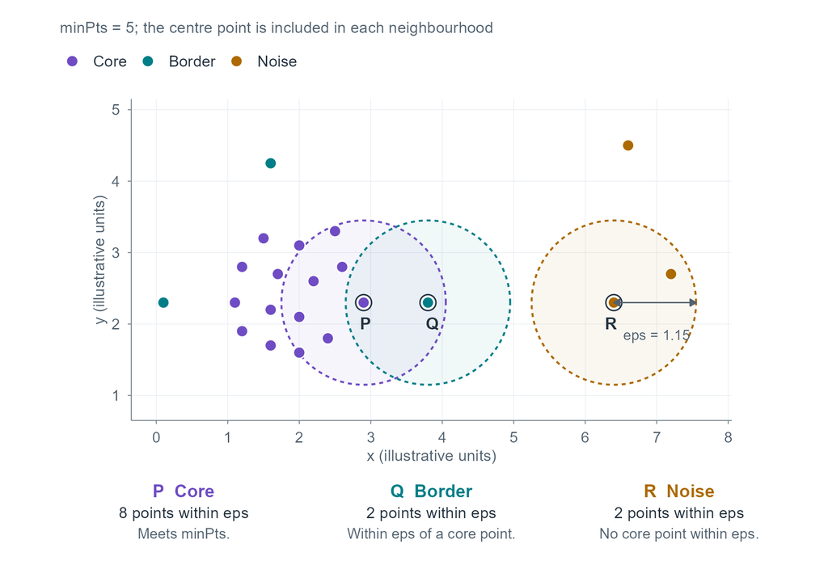

DBSCAN点类别（模拟）：相同半径下，P满足核心点条件，Q为边界点，R为噪声点；邻域计数包含自身。

**本章方法的衔接**：KDE把点平滑成连续强度表面；DBSCAN给点分配簇号，再决定是否为各簇生成AOI。两者的输出与参数含义不同。

#### **6.2 可复现模板**

按“读入与裁取 → 米制聚类 → 核查分类 → 投影凹包”的顺序运行。工作目录设为**第5章目录**；模板显式注册底图源，新会话无需依赖前面专题的对象。首次绘制瓦片需要联网，后续复用本地缓存。

DBSCAN在UTM 51N下计算，`eps = 500`的单位为米。凹包也在同一米制投影下生成，仅将展示副本转回经纬度。

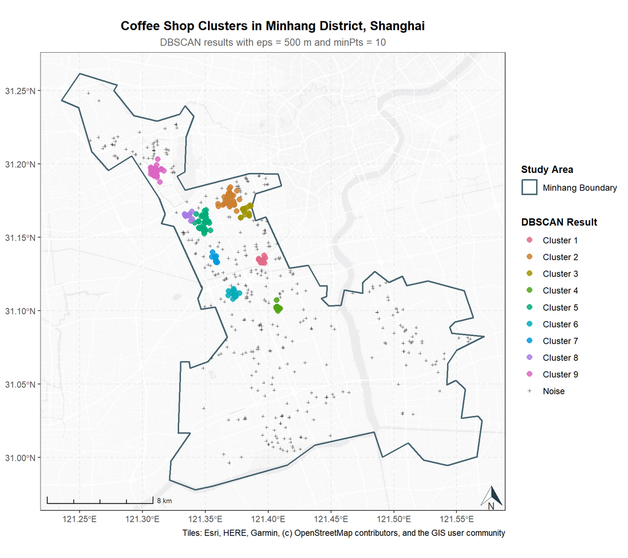

闵行咖啡POI的DBSCAN密度簇；eps = 500米、minPts = 10，噪声点单独显示。

**查看并复制DBSCAN聚类R代码**

```r
# ============================================================
# 1. 环境准备与依赖包加载
# ============================================================
# 缺少包时先在Console安装；本模板可在新的R会话中按顺序运行。
# install.packages(c("dbscan", "sf", "tidyverse", "ggspatial", "rosm"))
needed_packages <- c("dbscan", "sf", "tidyverse", "ggspatial", "rosm")
missing_packages <- needed_packages[
  !vapply(needed_packages, requireNamespace, logical(1), quietly = TRUE)
]
if (length(missing_packages)) {
  stop("请先安装：", paste(missing_packages, collapse = ", "))
}
library(dbscan)     # 密度聚类算法
library(sf)         # 空间数据读写与空间操作
library(tidyverse)  # 数据整理与可视化
library(ggspatial)  # 比例尺、指北针与瓦片底图

# 凹包需要sf提供st_concave_hull()，且其GEOS版本至少为3.11。
if (!"st_concave_hull" %in% getNamespaceExports("sf")) {
  stop("请更新sf：当前版本尚未提供st_concave_hull()。")
}
geos_version <- sub("-.*$", "", sf::sf_extSoftVersion()[["GEOS"]])
if (package_version(geos_version) < package_version("3.11.0")) {
  stop("凹包需要GEOS >= 3.11；请更新sf及其空间依赖。")
}

# 工作目录设为第5章；底图源在本模板中显式注册。
esri_light_gray_url <- paste0(
  "https://server.arcgisonline.com/ArcGIS/rest/services/Canvas/",
  "World_Light_Gray_Base/MapServer/tile/${z}/${y}/${x}"
)
rosm::register_tile_source(
  esri_light_gray = rosm::as.tile_source(
    esri_light_gray_url, extension = "jpg"
  )
)
dir.create(file.path("cache", "map_tiles"), recursive = TRUE, showWarnings = FALSE)

# ============================================================
# 2. 数据读取与研究范围裁取
# ============================================================
# 中文原字段只在读取后的 rename() 中出现；后续统一使用英文 snake_case。
# 原文件的 Shape_Leng / Shape_Area 单位未在字段中声明，保留 source_ 前缀，
# 避免把这两个来源属性直接解释为米或平方米。
shanghai_boundary <- st_read(
  "data/shanghai_boundary.geojson",
  quiet = TRUE
) %>%
  rename(
    object_id = OBJECTID_1,
    district_name = "县名",
    district_code = "县代码",
    city_name = "市名",
    city_code = "市代码",
    province_name = "省名",
    province_code = "省代码",
    source_shape_length = Shape_Leng,
    source_shape_area = Shape_Area
  ) %>%
  st_transform(4326) %>%
  st_make_valid()

# 行政区代码用于筛选，名称只用于地图标签；两者不能混用。
minhang_boundary <- shanghai_boundary %>%
  filter(district_code == 310112)
stopifnot(nrow(minhang_boundary) == 1L, !any(st_is_empty(minhang_boundary)))

# 读取咖啡店 POI，并统一转换为 WGS84 坐标系
poi_coffee <- st_read(
  "data/咖啡厅.geojson",
  quiet = TRUE
) %>%
  st_transform(4326)

# 空间裁取：仅保留位于闵行区范围内的咖啡店点位
stopifnot(
  all(st_geometry_type(poi_coffee) == "POINT"),
  !any(st_is_empty(poi_coffee)), all(st_is_valid(poi_coffee))
)
minhang_cafe <- st_filter(poi_coffee, minhang_boundary, .predicate = st_intersects)
stopifnot(nrow(minhang_cafe) > 0L)
# 保留合法POI；同名连锁店不据名称去重，重复ID或坐标需另行核查。

# ============================================================
# 3. DBSCAN 聚类计算
# ============================================================
# DBSCAN 的距离计算应在平面投影下完成，因此先转换为 UTM 51N
cafe_for_clustering <- minhang_cafe %>%
  st_transform(32651)

# 提取点坐标并转换为数值矩阵
coords <- st_coordinates(cafe_for_clustering)

# eps 的单位沿用投影坐标：500 表示 500 米的邻域半径。
# minPts 包含点本身；达到 10 个点才成为核心点，边界点仍可加入该簇。
# minPts 是函数原有参数名，调用时保留拼写；新建对象统一使用 snake_case。
db_res <- dbscan::dbscan(
  coords,
  eps = 500,
  minPts = 10
)

# 单独核查核心点；非核心但已归簇的点为边界点。
core_point <- dbscan::is.corepoint(coords, eps = 500, minPts = 10)

# 将聚类结果写回原始sf对象；此时行顺序与coords仍一致。
# cluster_id = 0表示当前参数下的噪声，其余整数只是簇标识。
minhang_cafe <- minhang_cafe %>%
  mutate(
    cluster_id = db_res$cluster,
    point_type = case_when(
      core_point ~ "核心点",
      cluster_id > 0 ~ "边界点",
      TRUE ~ "噪声点"
    ),
    cluster_label = if_else(
      cluster_id == 0,
      "Noise",
      paste0("Cluster ", cluster_id)
    )
  ) %>%
  # 按聚类编号排序，便于后续绘图时控制图层显示顺序
  arrange(cluster_id)

# ============================================================
# 4. 图例映射方案：颜色、形状与大小
# ============================================================
# 提取真实聚类编号（不含噪声点），颜色和图例均按同一编号顺序排列。
cluster_ids <- minhang_cafe %>%
  st_drop_geometry() %>%
  filter(cluster_id != 0) %>%
  pull(cluster_id) %>%
  unique() %>%
  sort()

# 为各聚类动态生成离散色盘
cluster_cols <- grDevices::hcl.colors(length(cluster_ids), palette = "Dark 3")
names(cluster_cols) <- paste0("Cluster ", cluster_ids)

# 设定噪声点颜色，并合并为统一的颜色映射表
plot_cols <- c("Noise" = "grey20", cluster_cols)

# 设定形状映射：噪声点为十字，聚类点为实心圆
plot_shapes <- c(
  "Noise" = 3,
  setNames(rep(16, length(cluster_ids)), names(cluster_cols))
)

# 设定大小映射：噪声点较小，聚类点相对更突出
plot_sizes <- c(
  "Noise" = 0.8,
  setNames(rep(2.5, length(cluster_ids)), names(cluster_cols))
)

# ============================================================
# 5. 可视化：闵行区咖啡店 DBSCAN 聚类结果
# ============================================================
# 使用本模板已注册的Esri浅灰底图；瓦片缓存可供后续复用。

ggplot() +
  # 5.1 底图图层
  annotation_map_tile(
    type = "esri_light_gray",
    zoom = 12,
    alpha = 0.40,
    cachedir = file.path("cache", "map_tiles"),
    quiet = TRUE
  ) +

  # 5.2 行政边界图层
  geom_sf(
    data = minhang_boundary,
    aes(linetype = "Minhang Boundary"),
    fill = NA,
    colour = "#496672",
    linewidth = 0.8,
    alpha = 0.8
  ) +

  # 5.3 点要素图层
  # 同时映射颜色、形状与大小，以保证图面与图例表达一致
  geom_sf(
    data = minhang_cafe,
    aes(
      color = cluster_label,
      shape = cluster_label,
      size = cluster_label
    ),
    alpha = 0.85
  ) +

  # 5.4 制图要素：比例尺与指北针
  annotation_scale(
    location = "bl",
    width_hint = 0.25,
    style = "ticks",
    text_cex = 0.6,
    text_col = "grey20"
  ) +
  annotation_north_arrow(
    location = "br",
    which_north = "true",
    height = grid::unit(0.8, "cm"),
    width = grid::unit(0.8, "cm"),
    pad_x = grid::unit(0.1, "cm"),
    pad_y = grid::unit(0.1, "cm"),
    style = north_arrow_orienteering(
      fill = c("white", "#253e49"),
      line_col = "#253e49",
      line_width = 0.6,
      text_col = "#253e49",
      text_size = 8
    )
  ) +

  # 5.5 图例与标度设置
  scale_linetype_manual(
    name = "Study Area",
    values = c("Minhang Boundary" = "solid")
  ) +
  scale_color_manual(
    name = "DBSCAN Result",
    values = plot_cols
  ) +
  scale_shape_manual(
    name = "DBSCAN Result",
    values = plot_shapes
  ) +
  scale_size_manual(
    name = "DBSCAN Result",
    values = plot_sizes
  ) +

  # 调整图例顺序，并覆盖边界图例的默认显示样式
  guides(
    linetype = guide_legend(
      override.aes = list(color = "#496672", linewidth = 0.8),
      order = 1
    ),
    color = guide_legend(order = 2),
    shape = guide_legend(order = 2),
    size = guide_legend(order = 2)
  ) +

  # 5.6 版式设置
  theme_bw() +
  theme(
    legend.position = "right",
    legend.title = element_text(size = 10, face = "bold"),
    legend.text = element_text(size = 9),
    plot.title = element_text(face = "bold", hjust = 0.5),
    plot.subtitle = element_text(color = "grey40", hjust = 0.5, size = 10),
    panel.grid.major = element_line(colour = "grey90", linetype = "dashed")
  ) +

  # 5.7 图题与附注
  labs(
    title = "Coffee Shop Clusters in Minhang District, Shanghai",
    subtitle = "DBSCAN results with eps = 500 m and minPts = 10",
    caption = paste(
      "Tiles: Esri, HERE, Garmin, (c) OpenStreetMap contributors,",
      "and the GIS user community"
    )
  )
```

##### 运行后先核查什么？

下表由本次对象计算。簇号用于区分组别，不表示规模排名；比较不同参数时，应按空间位置和点成员核对，不能直接把相同编号当作同一簇。

| 核查项 | 本次结果 |
| --- | --- |
| 原始咖啡POI | 4,950 |
| 闵行区内POI | 571 |
| 不同坐标 | 571 |
| 密度簇 | 9 |
| 已归簇点 | 190 |
| 核心点 | 138 |
| 边界点 | 52 |
| 噪声点 | 381 |
| 噪声点比例 | 66.7% |

**读图顺序**：先看簇的位置与点数，再看簇之间是否存在连续的核心点连接，最后查看未归簇点分布。本图中，已归簇点主要分布在研究区北部与中部，南部和东南部较多点未归簇。交通枢纽、办公与居住功能可作为后续核查线索；仅运行一组参数，还不能判断簇边界是否稳定。

##### 从簇点到聚类AOI

按簇汇总点，再计算凹包，得到每个簇的外轮廓。该AOI表示**算法选出的点集范围**；识别实际商圈还需经营联系、客流或调查资料。

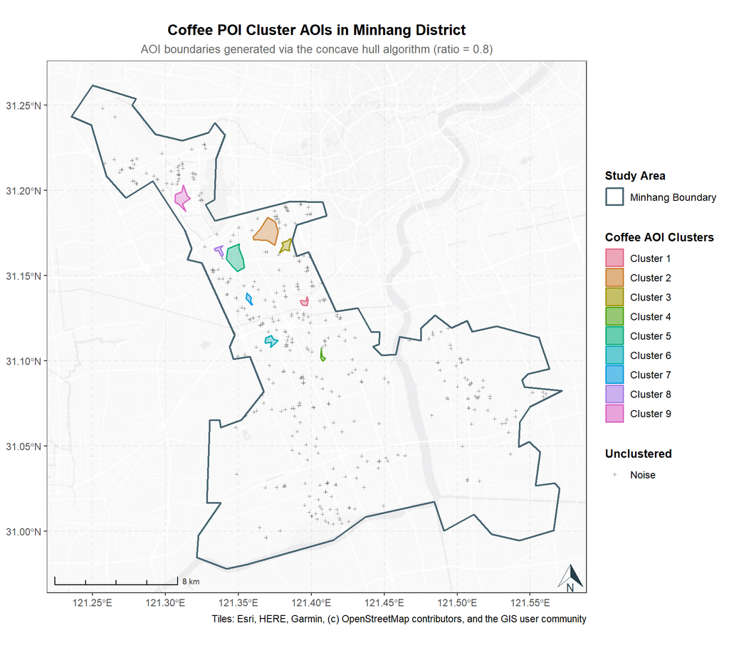

同一DBSCAN结果的聚类AOI；凹包在UTM 51N中计算，ratio = 0.8。

**查看并复制聚类AOI提取R代码**

```r
# ============================================================
# 6. 生成聚类AOI：在米制投影下计算凹包
# ============================================================
# 本块承接minhang_cafe和cluster_cols；凹包是簇点外轮廓。
cluster_points_projected <- minhang_cafe %>%
  filter(cluster_id != 0) %>%
  st_transform(32651)
if (!nrow(cluster_points_projected)) {
  stop("当前参数未形成聚类；先检查点图与参数，不生成空AOI。")
}

aoi_polygons_projected <- cluster_points_projected %>%
  group_by(cluster_label) %>%
  summarise(geometry = st_union(geometry), .groups = "drop") %>%
  # ratio在0至1之间；1对应凸包，较小值允许更明显的凹陷。
  # 不保留内部洞；这项设置不用于判断圈内是否处处存在活动。
  st_concave_hull(ratio = 0.8, allow_holes = FALSE)

stopifnot(
  all(st_is_valid(aoi_polygons_projected)),
  !any(st_is_empty(aoi_polygons_projected)),
  all(st_geometry_type(aoi_polygons_projected) %in% c("POLYGON", "MULTIPOLYGON"))
)
# 核对每个簇的输入点都被自身凹包覆盖，包含落在边界上的点。
aoi_hits <- st_covered_by(cluster_points_projected, aoi_polygons_projected)
own_aoi <- match(
  cluster_points_projected$cluster_label,
  aoi_polygons_projected$cluster_label
)
stopifnot(all(mapply(
  function(hit, own_index) own_index %in% hit,
  aoi_hits, own_aoi, USE.NAMES = FALSE
)))
# 分析保留米制几何；仅将显示副本转回经纬度。
aoi_polygons <- st_transform(aoi_polygons_projected, 4326)

# ============================================================
# 7. 可视化：闵行区咖啡POI聚类AOI
# ============================================================
ggplot() +
  # 7.1 底图图层
  annotation_map_tile(
    type = "esri_light_gray",
    zoom = 12,
    alpha = 0.40,
    cachedir = file.path("cache", "map_tiles"),
    quiet = TRUE
  ) +

  # 7.2 行政边界图层
  geom_sf(
    data = minhang_boundary,
    aes(linetype = "Minhang Boundary"),
    fill = NA,
    colour = "#496672",
    linewidth = 0.8,
    alpha = 0.8
  ) +

  # 7.3 聚类AOI多边形图层
  # 使用填充色与边框色同时区分不同聚类簇
  geom_sf(
    data = aoi_polygons,
    aes(
      fill = cluster_label,
      color = cluster_label
    ),
    alpha = 0.35,    # 保持一定透明度，便于识别底图信息
    linewidth = 0.6  # AOI 边界线宽
  ) +

  # 7.4 噪声点图层
  # 将未被聚类识别的点保留在图中，用作空间对照
  geom_sf(
    data = minhang_cafe %>% filter(cluster_id == 0),
    aes(shape = "Noise"),
    color = "grey30",
    size = 0.8,
    alpha = 0.6
  ) +

  # 7.5 制图要素：比例尺与指北针
  annotation_scale(
    location = "bl",
    width_hint = 0.25,
    style = "ticks",
    text_cex = 0.6,
    text_col = "grey20"
  ) +
  annotation_north_arrow(
    location = "br",
    which_north = "true",
    height = grid::unit(0.8, "cm"),
    width = grid::unit(0.8, "cm"),
    pad_x = grid::unit(0.1, "cm"),
    pad_y = grid::unit(0.1, "cm"),
    style = north_arrow_orienteering(
      fill = c("white", "#253e49"),
      line_col = "#253e49",
      line_width = 0.6,
      text_col = "#253e49",
      text_size = 8
    )
  ) +

  # 7.6 图例与标度设置
  scale_linetype_manual(
    name = "Study Area",
    values = c("Minhang Boundary" = "solid")
  ) +
  scale_fill_manual(
    name = "Coffee AOI Clusters",
    values = cluster_cols
  ) +
  scale_color_manual(
    name = "Coffee AOI Clusters",
    values = cluster_cols
  ) +
  scale_shape_manual(
    name = "Unclustered",
    values = c("Noise" = 3)
  ) +

  # 调整图例顺序，并统一图例显示样式
  guides(
    linetype = guide_legend(
      override.aes = list(color = "#496672", linewidth = 0.8),
      order = 1
    ),
    fill = guide_legend(
      order = 2,
      override.aes = list(alpha = 0.6)
    ),
    color = guide_legend(order = 2),
    shape = guide_legend(order = 3)
  ) +

  # 7.7 版式设置
  theme_bw() +
  theme(
    legend.position = "right",
    legend.title = element_text(size = 10, face = "bold"),
    legend.text = element_text(size = 9),
    plot.title = element_text(face = "bold", hjust = 0.5),
    plot.subtitle = element_text(color = "grey40", hjust = 0.5, size = 10),
    panel.grid.major = element_line(colour = "grey90", linetype = "dashed")
  ) +

  # 7.8 图题与附注
  labs(
    title = "Coffee POI Cluster AOIs in Minhang District",
    subtitle = "AOI boundaries generated via the concave hull algorithm (ratio = 0.8)",
    caption = paste(
      "Tiles: Esri, HERE, Garmin, (c) OpenStreetMap contributors,",
      "and the GIS user community"
    )
  )
```

**凸包与凹包怎样选？**

凸包是包住全部输入点的最小凸多边形；凹包允许边界向内凹陷，也应覆盖输入点。本例`ratio = 0.8`控制轮廓形态，`ratio = 1`对应凸包；`allow_holes = FALSE`不保留内部洞。圈内空白与范围是否合理，仍需回到原始点图检查。

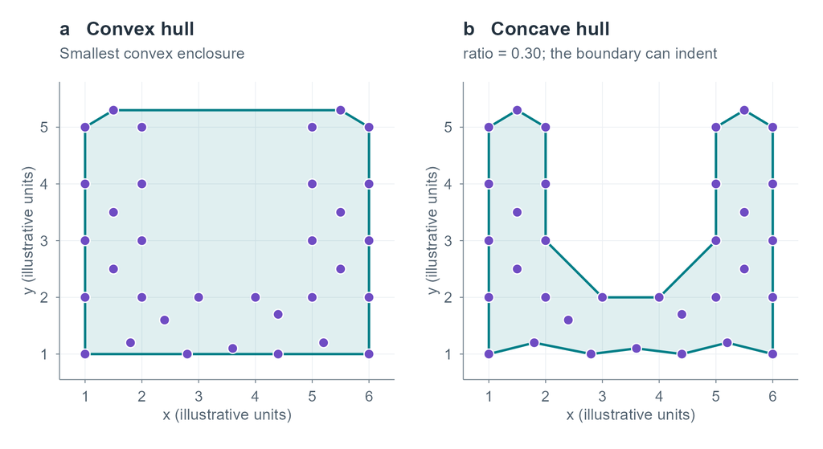

同一组模拟点的凸包与凹包：两者均覆盖全部输入点，凹包允许边界内凹；坐标仅为示意单位。

凹包生成后应检查几何有效性、输入点是否被自身AOI覆盖，以及边界是否越出研究区。凹包形状受参数控制，贴近点云不等于更接近真实商业边界。

##### 参数敏感性：每次只改变一项

以下是**尚未运行的对照设计**。固定同一批POI、研究区与投影，先选择其中一行实施即可。

| 改变什么？ | 候选与固定条件 | 报告什么？ |
| --- | --- | --- |
| 邻域半径`eps` | 300、500、700米；固定`minPts = 10`。 | 簇数、噪声比例、最大簇点数占比，以及合并／分裂位置。 |
| 点数门槛`minPts` | 5、10、15；固定`eps = 500`米。 | 哪些簇或边界点改变，哪些区域仍然聚集。 |
| 凹包`ratio` | 0.5、0.8、1；固定原聚类结果，不重新聚类。 | AOI面积与外轮廓改变；点的簇号应保持不变。 |

半径越大、门槛越低，通常更容易连接点，但这不保证结果更合适。可用`dbscan::kNNdistplot(coords, k = 9)`查看第9个其他邻居的距离分布，辅助寻找`minPts = 10`时的候选半径；曲线转折只是线索，还需结合位置、数据量与研究尺度判断。边界附近的截点影响可参照专题2的通用反思。

**方法与阅读**

- **操作入口**：[dbscan官方教程](https://cran.r-project.org/web/packages/dbscan/vignettes/dbscan.html)；先读邻域、参数和点类型，再查看k近邻距离图。
- **R实现**：Hahsler、Piekenbrock与Doran（2019），*dbscan: Fast Density-Based Clustering with R*，*Journal of Statistical Software, 91*(1), 1–30。[论文](https://doi.org/10.18637/jss.v091.i01)。
- **算法与参数讨论**：[Ester等（1996）原始论文](https://dl.acm.org/doi/10.5555/3001460.3001507)；[Schubert等（2017）方法回顾](https://doi.org/10.1145/3068335)。
- **凹包参数与依赖**：[sf几何运算文档](https://r-spatial.github.io/sf/reference/geos_unary.html)，查看`st_concave_hull()`的`ratio`、`allow_holes`与GEOS版本要求。

#### **6.3 进阶练习：自选空间点数据专题**

> 本部分**不再提供现成代码**。请结合本章已经学习的点数据分析方法，自主完成一个小型专题研究。

本章已经涉及点数据读取与裁取、六边形聚合、核密度估计 （KDE）、AOI 提取、邻近性测度以及DBSCAN 聚类等方法。本练习的目标，不再是单一步骤的复现，而是尝试将这些方法围绕一个明确问题进行组合应用。

##### **6.3.1 任务要求**

请从课程数据页面  
https://dawn-ecnu.github.io/data/  
中选择一个或多个点数据图层 （也可使用本章已出现的数据），围绕某一具体空间问题完成一次自主分析。

**建议选题方向** （任选其一，也可自行设计）：

- **方向 A：商业集聚识别**  
  选择某一类 POI （如咖啡店、餐饮、便利店等），识别其在指定区域内的高密度集聚区，并比较 `KDE` 与 `DBSCAN` 的结果差异。
- **方向 B：热点与边界提取**  
  基于点密度结果提取热点范围 （AOI），讨论不同参数设定下边界形态的变化，并解释其空间含义。
- **方向 C：点数据与城市设施关系**  
  将某类活动点或商业点与公共交通设施 （如地铁站、公交站）结合，分析其是否更倾向于在可达性较高区域集聚。

##### **6.3.2 硬性要求（Checklist）**

你的 `R Markdown` 报告至少应包含以下内容：

1. **研究对象与问题界定**  
   明确说明你选择了什么点数据，研究范围是什么，以及核心问题是什么。
2. **数据处理过程**  
   包括数据读取、坐标系检查、研究范围裁取，以及必要的数据清洗步骤。
3. **至少使用一种密度或聚类方法**  
   可在以下方法中至少选择一种：
   - KDE （Kernel Density Estimation）
   - DBSCAN
   - 六边形聚合 （Hexagonal Aggregation）
4. **至少加入一个补充分析模块**  
   例如：
   - AOI 边界提取
   - 最近邻距离或设施可达性比较
   - 不同区域之间的聚集强度对比
   - 不同参数设定下结果的敏感性分析
5. **结果输出与解释**  
   至少输出 **2 张图**，并用简短文字总结主要发现：
   - 是否存在明显集聚区？
   - 热点主要位于何处？
   - 不同方法得到的结果是否一致？
   - 这些空间格局可能与哪些城市功能特征有关？

#### **6.4 知识点自测**

以下六题回顾点记录、空间聚合、空间关联、密度估计与聚类。每题选择一项，点击“检查答案”查看解析；题目考查方法判断，无需记忆案例数值。

01基础 · 点记录与坐标一份签到 sf 数据已正确声明为 EPSG:4326，每行代表一次签到。两行坐标相同，但时间不同。准备计算米制距离，哪种处理合适？ A．按坐标去重，再用 `st_set_crs(32651)` 把坐标改成米。 B．保留两次签到，转换到当地合适的米制投影后计算距离。 C．保留两次签到，将经纬度差直接当作米制距离。 D．点的几何维度为0，不能计算点间距离。

02基础至中等 · 空间聚合同一批点分别汇总到两套正六边形。两套网格面积、方向相同，只平移网格起点；部分高值格的位置随后改变。哪种解释合适？ A．属于尺度效应，因为每格纳入的点数发生了变化。 B．原始点的位置发生了变化，应先修复定位错误。 C．属于分区效应，需比较重新归格后哪些模式保持稳定。 D．高值格变少的方案更准确，应采用该方案。

03中等 · 代码判断已筛选有效六边形，并按 `hex_analysis` 的当前行序构建空间权重。随后运行 `price <- sort(hex_analysis$median_price)`，准备将 price 与原权重一起用于 Moran 分析。这一步有什么问题？ A．没有问题；只要代码可以运行，排序就不会影响空间分析。 B．没有问题；权重会自动随价格向量重新排序。 C．价格与权重可能错位；应保持价格、几何与权重的对应顺序。 D．需要先把不足点数门槛的格补为零价格，才能使用原权重。

04较难 · 全局与局部关联某研究的全局 Moran’s I 显著为正。一个格在 Moran 散点图的HH象限，但其局部检验经多重比较调整后未达到0.05门槛。哪项解释合适？ A．全局检验已经显著，该格应直接标为显著HH。 B．该格未显著，说明全局正向关联的结果有误。 C．该格价格受到邻格价格的因果影响。 D．整体存在正向空间关联，该格的HH方向尚未通过局部显著性判断。

05较难 · KDE与AOI研究固定一份KDE表面，以区内等面积评价网格密度的第95百分位为阈值，提取高值AOI。下列哪项理解准确？ A．AOI必须恰好包含95%的原始点。 B．AOI对应网格密度排名靠前的范围，点的覆盖比例需另行统计。 C．AOI内的密度均已通过显著性水平0.05的检验。 D．将KDE带宽加倍后，只需更换色盘，原AOI仍可沿用。

06中等 · 聚类与代码points_m 已转换到当地合适的米制投影。运行 `dbscan::dbscan(sf::st_coordinates(points_m), eps = 300, minPts = 5)`。点P的300米邻域内连同自身共有4个点，但P位于一个核心点的300米邻域内。P应怎样分类？ A．边界点。 B．核心点，因为 `minPts` 不包含自身。 C．噪声点，因为它自身邻域不足5点。 D．无法判断，因为代码没有指定聚类个数。

**© 华东师范大学 社会发展学院 人口研究所** | [**DAWN 研究组**](https://dawn-ecnu.github.io) | yzliu@soci.ecnu.edu.cn

课程负责人：刘贇喆 本章作者：刘贇喆 | 敖漪宇

最后更新：2026年10月20日 构建环境：R version 4.6.1 (2026-06-24 ucrt)

[CC BY-NC-SA 4.0](https://creativecommons.org/licenses/by-nc-sa/4.0/deed.zh) 回到顶部